# Final Blog Post

Tomonori Miyamoto

2023-12-22

# Norm Cascades on ILO Conventions

International norms have a life cycle. While we often find an instance of the “norm cascades” [(Finnemore and Sikkink)](https://www.jstor.org/stable/2601361), the mechanism behind this tendency is not necessarily clear. This blog-post discusses whether trade agreements can accelerate the norm cascades through the analysis of the ratification of ILO conventions.

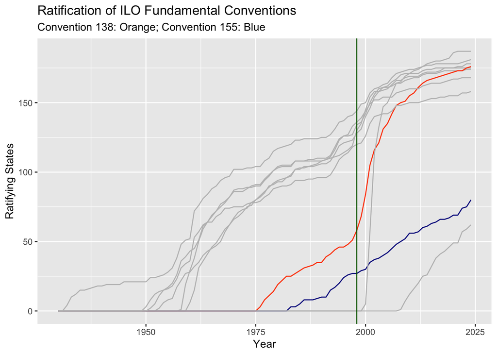

[ILO](https://www.ilo.org/global/standards/introduction-to-international-labour-standards/conventions-and-recommendations/lang--en/index.htm) identified eight conventions in 1998 and two conventions in 2022 as the “fundamental” conventions. As the graph above shows, the number of ratifying countries of Convention 138 (identified as “fundamental” in 1998) increased significantly from around 1998, while that of Convention 155 kept increasing at a constant pace. We may say that the year 1998 is a “tipping point” for Convention 138.

At the same time, many trade agreements started to be established, and regulations on the working environment are one of the main issues for trade negotiations. Now, the following two hypotheses are suggested.

H1: Trade agreements significantly contribute to the ratification trend of the convention. H2: States ratifying the convention for some reasons are likely to form trade agreements.

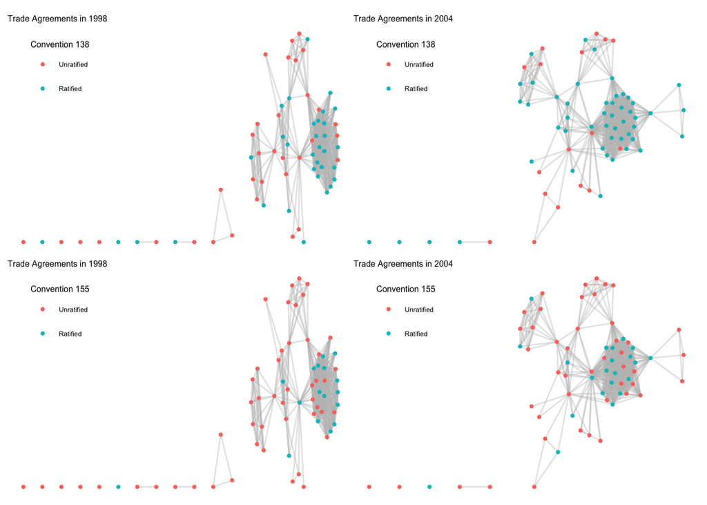

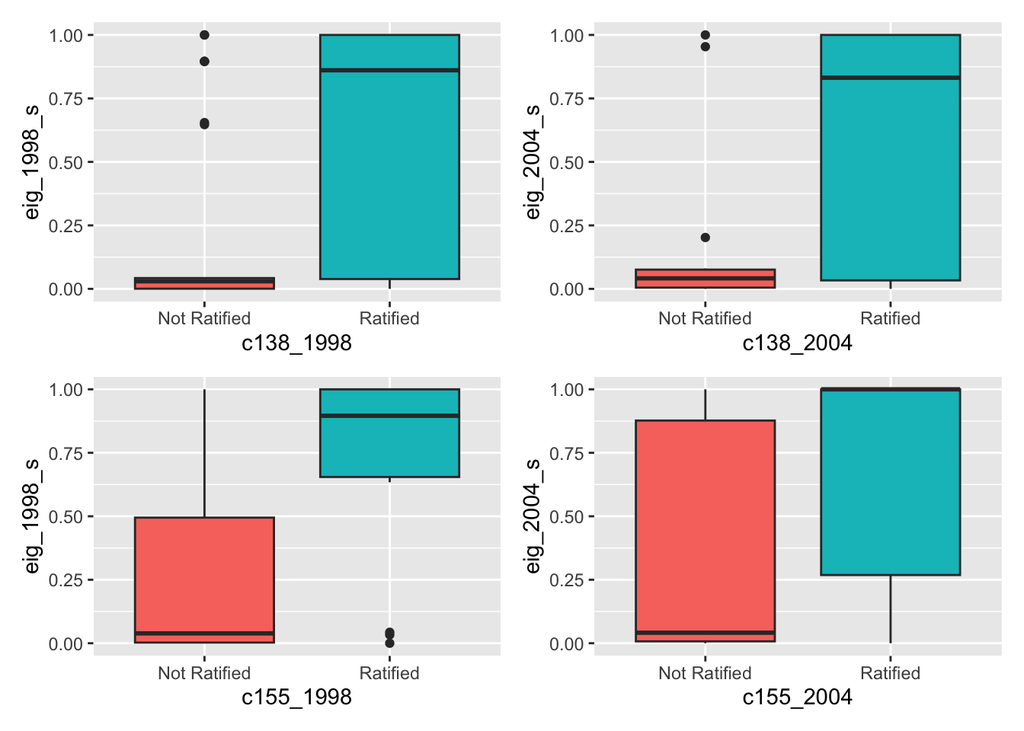

# Network Observation

Before specifying the model, let’s take a look at the network compositions to confirm that trade agreements can be influential in this environment. The graphs of the networks suggest that the main component contains both ratifying and non-ratifying countries, and the number of isolated nodes is limited. The box plots obtained from the network data indicate that states which ratified these conventions tend to have higher eigenvector centrality, which suggests that they are in an influential position. These characteristics align with the possibility that trade agreements contribute to the trend of ratification.

# Model Specification

The notable parameters included in the model of this blog-post are as follows:

GDP (ego; ego and alter) GDP may affect the results in two ways: decreasing the inclination because the huge domestic market allows the government to avoid seeking trade opportunities [(Manger and Pickup)](https://doi.org/10.1177/0022002714535431) and increasing the attractivity as a trade partner.

Trade agreements and their partners (average alter) on the behaviour variable These terms are connected with H1. Positive values here will imply that the behaviour (ratification of the convention) of states affects the behaviour of their trade partners. EU’s soft approach on labour regulations [Postnikov and Bastiaens](https://doi.org/10.1080/13501763.2014.910869) may be related. The dependent variable here is the behaviour of ratification of the ILO convention. Therefore, some variables may affect the results, for example: - GDP per capita (ego) - Index on polity/democracy - the value of average alter interacted with GDP (alter) However, these effects are not significant in the trials, so they are excluded in this model.

All related data is from the [World Bank](https://databank.worldbank.org/) and the [ILO](https://www.ilo.org/dyn/normlex/en/f?p=1000:12001::::::). In order to make the size of data manageable, only states which are categorised as high-income and upper-middle-income countries are selected. Because of time and resource limitation, the number of iteration is 1000 for each model, which affects the convergence and goodness of fit of the model.

# Model is determined!

model is determined!

```
## # A tibble: 13 × 14
##    dv       term       estc138p1 sec138p1 tstc138p1 estc138p2 sec138p2 tstc138p2
##    <chr>    <chr>      <chr>     <chr>    <chr>     <chr>     <chr>    <chr>
##  1 "PTAp1"  constant … 1.131     "0.283"  "3.991"   2.057     "0.456"  "4.515"
##  2 "PTAp1"  constant … 1.949     "0.45"   "4.33"    4.053     "0.586"  "6.912"
##  3 "PTAp1"  number of… -0.142    "0.022"  "-6.564"  -0.39     "0.052"  "-7.567"
##  4 "PTAp1"  C138p1 ego 1.845     "1.173"  "1.573"   1.543     "0.738"  "2.092"
##  5 "PTAp1"  C138p1 eg… -0.851    "0.579"  "-1.47"   0.262     "0.499"  "0.525"
##  6 "PTAp1"  GDPp1 ego  0.573     "0.127"  "4.522"   0.396     "0.099"  "3.985"
##  7 "PTAp1"  GDPp1 ego… 0.031     "0.014"  "2.113"   0.023     "0.013"  "1.681"
##  8 "C138p1" rate C138… 0.1       ""       ""        1.75      "0.832"  "2.104"
##  9 "C138p1" rate C138… 0.128     "0.06"   "2.138"   0.445     "0.281"  "1.58"
## 10 "C138p1" C138p1 de… 77.367    "27.613" "2.802"   -0.022    "0.073"  "-0.307"
## 11 "C138p1" C138p1 av… 222.04    "1.013"  "219.279" 5.687     "2.317"  "2.455"
## 12 ""       tmax       3.556     ""       ""        0.096     ""       ""
## 13 ""       tconv.max  3.651     ""       ""        0.166     ""       ""
## # ℹ 6 more variables: estc155p1 <chr>, sec155p1 <chr>, tstc155p1 <chr>,
## #   estc155p2 <chr>, sec155p2 <chr>, tstc155p2 <chr>
```

```
## Note: some statistics are not plotted because their variance is 0.
## This holds for the statistic: Inf.
```

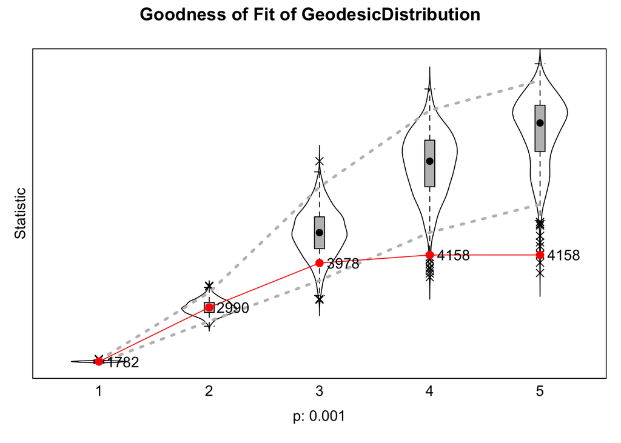

```
## Note: some statistics are not plotted because their variance is 0.
## This holds for the statistic: Inf.
```

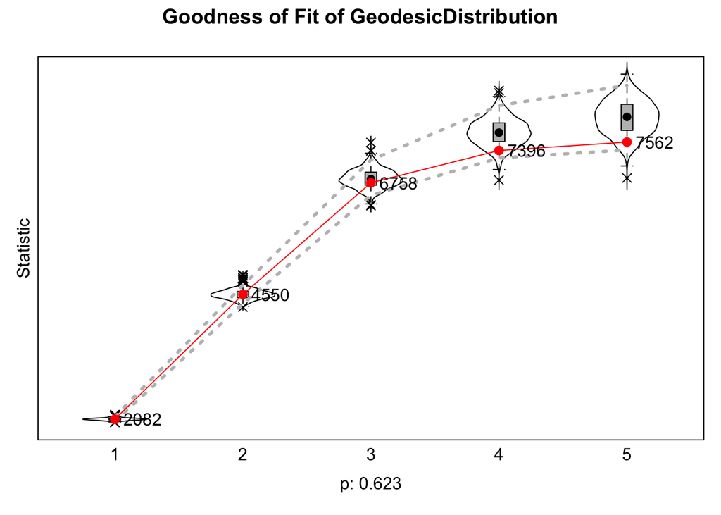

```
## Note: some statistics are not plotted because their variance is 0.
## This holds for the statistic: Inf.
```

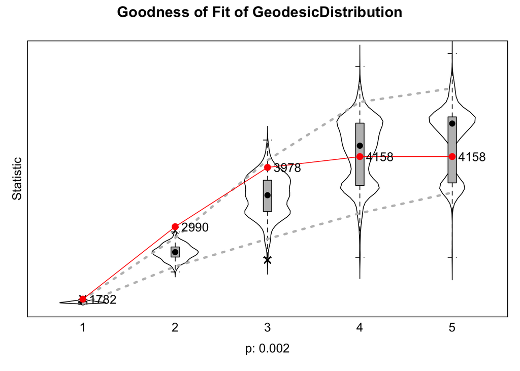

```
## Note: some statistics are not plotted because their variance is 0.
## This holds for the statistic: Inf.
```

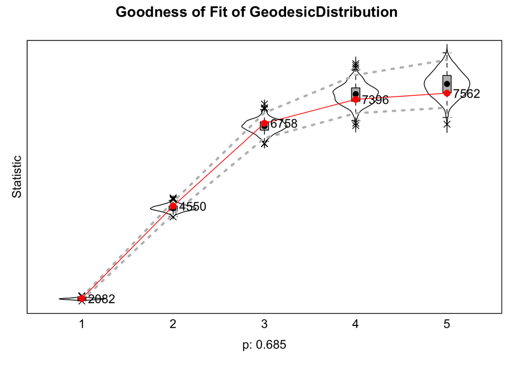

# Results and Discussion

As the table shows, this model did not bring the expected results. Although some results of Goodness of Fit of Geodesic Distribution have good results, the maximum convergence t-ration among the parameters is much higher than 0.1, and the overall maximum convergence ratio is much higher than 0.25 in most models. Some parameters are significant (the absolute value of the t-stats is bigger than 2), but they have huge errors, and the model is not converged enough, so they are not reliable to use. Other than the lack of iterations, a low level of convergence may suggest the existence of some issues in this model, including multi-colinearity.

One of the biggest reasons should be the selection of states. This model only considers upper-middle- and high-income countries, which brings some bias, especially focusing too much on the EU member states. Although handling the EU as a single state can be a solution, the status of ratification of ILO conventions is different between member states. Therefore, finding good measures to deal with the difference between the EU, other than taking the mean simply, might be a breakthrough of this analysis. In addition, obtaining and using some reasonable control variables to improve the model for trade agreements should also be considered.